# Data analysis on forest fires

```python
# importing modules
import pandas as pd #install pandas using pip
import numpy as np #numpy module is used to perform sum on rows/columns
import matplotlib.pyplot as plt #to plot graphs
import seaborn as sns
```

## Data cleaning

```python
df = pd.read_csv(r"D:\Data anlaysis on forest fires\archive\amazon.csv")   #importing the csv file
```

```python
df
```

|  | year | state | month | number | date |
| --- | --- | --- | --- | --- | --- |
| 0 | 1998 | Acre | Janeiro | 0.0 | 1998-01-01 |
| 1 | 1999 | Acre | Janeiro | 0.0 | 1999-01-01 |
| 2 | 2000 | Acre | Janeiro | 0.0 | 2000-01-01 |
| 3 | 2001 | Acre | Janeiro | 0.0 | 2001-01-01 |
| 4 | 2002 | Acre | Janeiro | 0.0 | 2002-01-01 |
| ... | ... | ... | ... | ... | ... |
| 6449 | 2012 | Tocantins | Dezembro | 128.0 | 2012-01-01 |
| 6450 | 2013 | Tocantins | Dezembro | 85.0 | 2013-01-01 |
| 6451 | 2014 | Tocantins | Dezembro | 223.0 | 2014-01-01 |
| 6452 | 2015 | Tocantins | Dezembro | 373.0 | 2015-01-01 |
| 6453 | 2016 | Tocantins | Dezembro | 119.0 | 2016-01-01 |

6454 rows × 5 columns

```python
df.dtypes
```

```
year        int64
state      object
month      object
number    float64
date       object
dtype: object
```

```python
df.shape
```

```
(6454, 5)
```

```python
#checking for missing/null values
df.isna().sum()
```

```
year      0
state     0
month     0
number    0
date      0
dtype: int64
```

There are no missing values in this dataset

```python
# checking if there are any duplicate values
df.duplicated().sum()
```

```
32
```

There are 32 duplicate rows

```python
# deleting the duplicate rows
df = df.drop_duplicates()
```

```python
df.shape
```

```
(6422, 5)
```

# Data analysis

- Total no. of fires by state

```python
# goruping the data
pivot1 = pd.pivot_table(df,values = "number",index = ["state"], aggfunc=np.sum)
pivot1 = pivot1.rename(index={'Par�':'Pará'})
pivot1
```

| state | number |
| --- | --- |
| Acre | 18464.030 |
| Alagoas | 4606.000 |
| Amapa | 21831.576 |
| Amazonas | 30650.129 |
| Bahia | 44746.226 |
| Ceara | 30428.063 |
| Distrito Federal | 3561.000 |
| Espirito Santo | 6546.000 |
| Goias | 37695.520 |
| Maranhao | 25129.131 |
| Mato Grosso | 96246.028 |
| Minas Gerais | 37475.258 |
| Paraiba | 52426.918 |
| Pará | 24512.144 |
| Pernambuco | 24498.000 |
| Piau | 37803.747 |
| Rio | 45094.865 |
| Rondonia | 20285.429 |
| Roraima | 24385.074 |
| Santa Catarina | 24359.852 |
| Sao Paulo | 51121.198 |
| Sergipe | 3237.000 |
| Tocantins | 33707.885 |

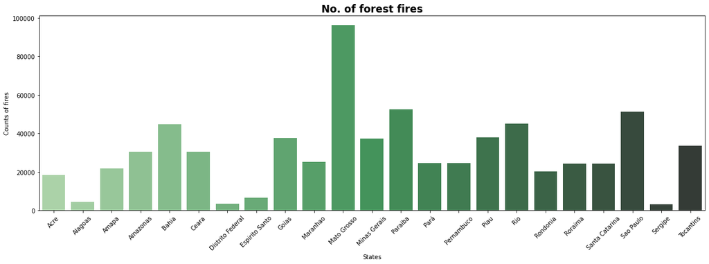

```python
#plotting a graph
plt.figure(figsize=(20,6))
ax = sns.barplot(x=pivot1.index, y='number', data=pivot1,palette='Greens_d')
ax.set_xticklabels(ax.get_xticklabels(), rotation=45)
ax.set_xlabel('States')
ax.set_ylabel('Counts of fires')
ax.set_title('No. of forest fires',fontdict={'fontsize': '17', 'fontweight' : 'bold'})
```

Conclusions:

1. Large no. of forest fires occur in Manto Grosso
2. Alagaos, Distritio Fedaral,Espririto Santo and Sergipe see a small no. of fires

Study: One of the reasons as to why some states have more forest fires than other can be due to forestation in that area. Brazil is divied into five regions namely North, Northeast, Central west, South, Southeast. Forests are reletively more denser in North and Northeast compared to other regions.

Does this hold true?

- Analysis by region

```python
# dividing states by region
states = pivot1.index
state_region = ['North','Northeast','North','North','Northeast','Northeast','Centralwest','Southeast','Centralwest','Northeast',
                'Centralwest','Southeast','Northeast','North','Northeast','Northeast','Southeast','North','North','South',
                'Southeast','Northeast','North']
state_index = 0

for i in states:
    pivot1.loc[(pivot1.index==i),'Region'] = state_region[state_index]
    state_index = state_index + 1
pivot1
```

| state | number | Region |
| --- | --- | --- |
| Acre | 18464.030 | North |
| Alagoas | 4606.000 | Northeast |
| Amapa | 21831.576 | North |
| Amazonas | 30650.129 | North |
| Bahia | 44746.226 | Northeast |
| Ceara | 30428.063 | Northeast |
| Distrito Federal | 3561.000 | Centralwest |
| Espirito Santo | 6546.000 | Southeast |
| Goias | 37695.520 | Centralwest |
| Maranhao | 25129.131 | Northeast |
| Mato Grosso | 96246.028 | Centralwest |
| Minas Gerais | 37475.258 | Southeast |
| Paraiba | 52426.918 | Northeast |
| Pará | 24512.144 | North |
| Pernambuco | 24498.000 | Northeast |
| Piau | 37803.747 | Northeast |
| Rio | 45094.865 | Southeast |
| Rondonia | 20285.429 | North |
| Roraima | 24385.074 | North |
| Santa Catarina | 24359.852 | South |
| Sao Paulo | 51121.198 | Southeast |
| Sergipe | 3237.000 | Northeast |
| Tocantins | 33707.885 | North |

```python
pivot1.Region.value_counts()
```

```
Northeast      8
North          7
Southeast      4
Centralwest    3
South          1
Name: Region, dtype: int64
```

Yes, there are more Northeast and North rows within the dataset. Does this reflect on the no. of fires?

```python
# Number of fires by Region
region = pd.pivot_table(pivot1, values='number',index=['Region'],aggfunc=np.sum)
region.sort_values(by='number',ascending=False)
```

| Region | number |
| --- | --- |
| Northeast | 222875.085 |
| North | 173836.267 |
| Southeast | 140237.321 |
| Centralwest | 137502.548 |
| South | 24359.852 |

- Total no. of fires by month

```python
#translating the month names
# If the months are mapped SettingWithCopy warning arises

portuguese_month = df.month.unique()
english_months = ['January','February', 'March', 'April', 'May', 'June', 'July',
                   'August', 'September', 'October', 'November', 'December']

month_index=0

for p_month in portuguese_month:
    df.loc[(df.month == p_month),'month'] = english_months[month_index]
    month_index = month_index + 1
```

```python
# checking if the months are in order
df.month.unique()
```

```
array(['January', 'February', 'March', 'April', 'May', 'June', 'July',
       'August', 'September', 'October', 'November', 'December'],
      dtype=object)
```

```python
# aggregating the data
pivot2 = pd.pivot_table(df,values = "number",index = ["month"], aggfunc=np.sum)
#arranging the data(months) in order
pivot2.index = pd.CategoricalIndex(pivot2.index, categories = english_months, ordered = True)
pivot2 = pivot2.sort_index()
```

```python
pivot2
```

| month | number |
| --- | --- |
| January | 47681.844 |
| February | 30839.050 |
| March | 30709.405 |
| April | 28184.770 |
| May | 34725.363 |
| June | 55997.675 |
| July | 92319.113 |
| August | 88050.435 |
| September | 58578.305 |
| October | 88681.579 |
| November | 85508.054 |
| December | 57535.480 |

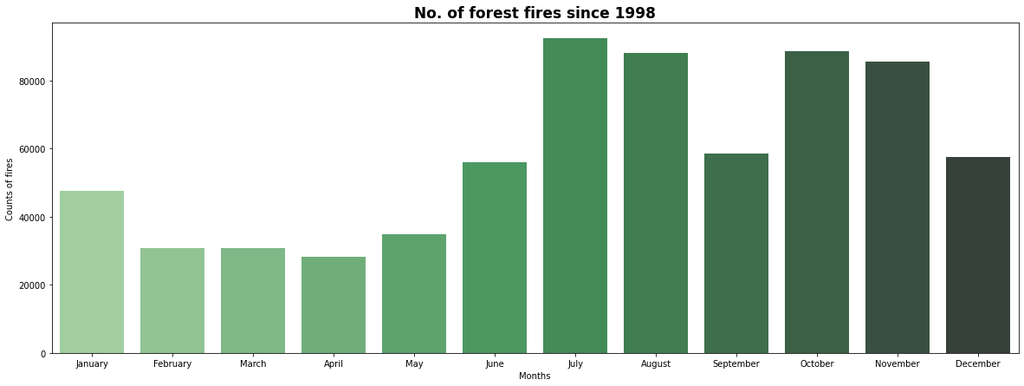

```python
#plotting a graph
plt.figure(figsize=(20,7))
ax = sns.barplot(x=pivot2.index, y='number', data=pivot2,palette='Greens_d')
ax.set_xlabel('Months')
ax.set_ylabel('Counts of fires')
ax.set_title('No. of forest fires since 1998',fontdict={'fontsize': '17', 'fontweight' : 'bold'})
```

Conclusions:

1. In February,March,April and May the lowest no. of forest fires occured
2. In the four months(July,august,October and November) the maximum no. forest fires occured
3. There is a sudden increase in July.
4. It is observed that the no. of fires are more in the latter half of the year.

Discussion:

- Observing temperatures in brazil

```python
state1 = pd.read_csv(r"D:\Data anlaysis on forest fires\archive\station_rio.csv")
state2 = pd.read_csv(r"D:\Data anlaysis on forest fires\archive\station_sao_paulo.csv")
```

```python
rio_temp = state1.iloc[35:42,1:13].apply(np.mean)
rio_temp = rio_temp.reset_index()
rio_temp = rio_temp.rename(columns={0:'Temp'})

sao_paulo_temp = state2.iloc[61:67,1:13].apply(np.mean)
sao_paulo_temp = sao_paulo_temp.reset_index()
sao_paulo_temp = sao_paulo_temp.rename(columns={0:'Temp'})
```

```python
sao_paulo_temp
```

|  | index | Temp |
| --- | --- | --- |
| 0 | JAN | 23.538333 |
| 1 | FEB | 24.943333 |
| 2 | MAR | 23.813333 |
| 3 | APR | 22.083333 |
| 4 | MAY | 19.056667 |
| 5 | JUN | 17.905000 |
| 6 | JUL | 18.275000 |
| 7 | AUG | 19.420000 |
| 8 | SEP | 20.541667 |
| 9 | OCT | 21.723333 |
| 10 | NOV | 22.258333 |
| 11 | DEC | 23.673333 |

```python
rio_temp
```

|  | index | Temp |
| --- | --- | --- |
| 0 | JAN | 27.182857 |
| 1 | FEB | 28.188571 |
| 2 | MAR | 26.464286 |
| 3 | APR | 25.005714 |
| 4 | MAY | 22.722857 |
| 5 | JUN | 21.610000 |
| 6 | JUL | 21.257143 |
| 7 | AUG | 22.075714 |
| 8 | SEP | 22.964286 |
| 9 | OCT | 24.095714 |
| 10 | NOV | 24.942857 |
| 11 | DEC | 26.705714 |

- plotting graphs

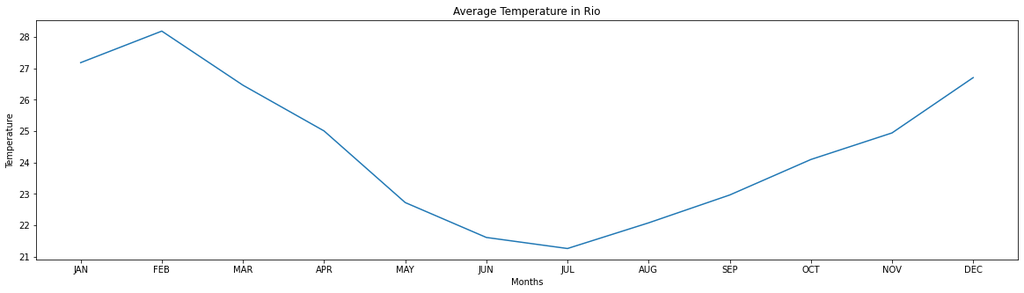

```python
plt.figure(figsize=(20,5))
ax = sns.lineplot(x = 'index', y = 'Temp' , data = rio_temp)
ax.set_xlabel('Months')
ax.set_ylabel('Temperature')
ax.set_title('Average Temperature in Rio')
```

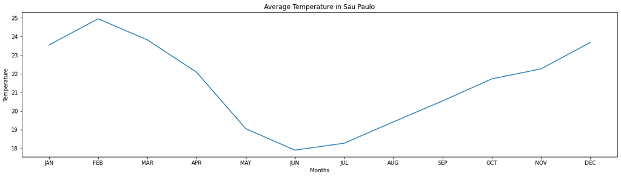

```python
plt.figure(figsize=(20,5))
ax = sns.lineplot(x = 'index', y = 'Temp' , data = sao_paulo_temp)
ax.set_xlabel('Months')
ax.set_ylabel('Temperature')
ax.set_title('Average Temperature in Sau Paulo')
```

- Total no. of fires by year

```python
pivot3 = pd.pivot_table(df,values = "number",index = ["year"], aggfunc=np.sum)
pivot3
```

| year | number |
| --- | --- |
| 1998 | 20013.971 |
| 1999 | 26882.821 |
| 2000 | 27351.251 |
| 2001 | 29054.612 |
| 2002 | 37390.600 |
| 2003 | 42760.674 |
| 2004 | 38450.163 |
| 2005 | 35004.965 |
| 2006 | 33824.161 |
| 2007 | 33028.413 |
| 2008 | 29378.964 |
| 2009 | 39116.178 |
| 2010 | 37037.449 |
| 2011 | 34633.545 |
| 2012 | 40084.860 |
| 2013 | 35137.118 |
| 2014 | 39621.183 |
| 2015 | 41208.292 |
| 2016 | 42212.229 |
| 2017 | 36619.624 |

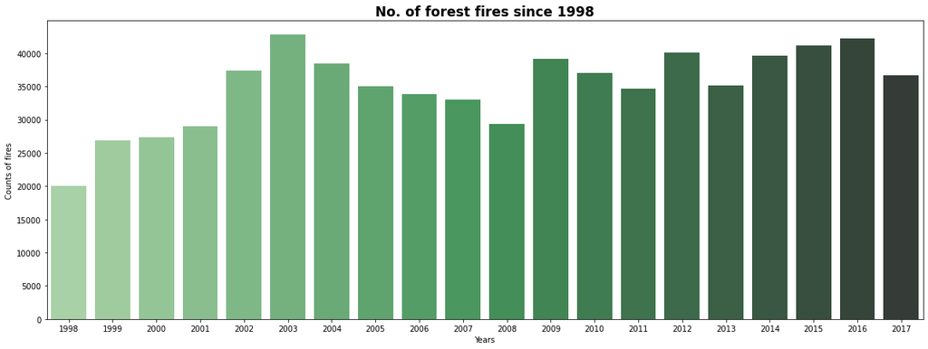

```python
#plotting a graph
plt.figure(figsize=(20,7))
ax = sns.barplot(x=pivot3.index, y='number', data=pivot3,palette='Greens_d')
ax.set_xlabel('Years')
ax.set_ylabel('Counts of fires')
ax.set_title('No. of forest fires since 1998',fontdict={'fontsize': '17', 'fontweight' : 'bold'})
```